# Master Seminar in Marketing

Simulations challenging the DAG framework

Stefan Glaisner (4222790)

05-11-2022

# Introduction to the DAG framework

*DAG* = Directed Acyclic Graphs

## Main Terminology

- All nodes that have arrows going directly into another node are this node’s *parents*.
- *Ancestors* of a node include parents of that node, their parents, and so on.
- For any given node all the nodes that have arrows going into them directly from the given node are its *children*.
- *Descendants* of a node include its children, their children, and so on.
- A *collider* of a path is an non-endpoint node on that path with arrows from that path going into the node, but no arrows from that path emerging from that node. Z2 is a collider on the path (X -> Z2 <- Z1).
- A *non-collider* of a path is an non-endpoint node on a path that is not a collider.
  - Note that a node X can be a collider on one path from Z to Y and the same node can be a non-collider on a different path from Z to Y, so that clearly being a collider is not an intrinsic feature of a node relative to two other nodes, it also depends on the path (i.e. X is a collider on the path Z -> X <- U -> Y and a non-collider on the path Z -> X -> Y.
- A *directed path* is a path where the arrows all go in the same direction.
- A *back-door path* from node A to node B is a path from A to B that starts with an incoming arrow into A and ends with an incoming arrow into B (i.e. the path (X <- Z0 -> Z1 -> Z2) is a back-door path from X to Z2).
  - A back-door path must contain at least one non-collider, although in general it may contain both colliders and non-colliders.
- *d-separation / d-connection*: When two nodes are *d-separated*, they (or the variables they represent) are definitely independent. When two nodes are *d-connected*, they are possibly, or most likely, dependent.

## Rules in Graphical Models

**Rule 1: Conditional Independence in Chains**: Two variables, X and Y, are conditionally independent given Z, if there is only one unidirectional path between X and Y and Z is any set of variables that intercepts that path.  
**Rule 2: Conditional Independence in Forks**: If a variable X is a common cause of variables Y and Z, and there is only one path between Y and Z, then Y and Z are independent conditional on X.  
**Rule 3: Conditional Independence in Colliders**: If a variable Z is the collision node between two variables X and Y, and there is only one path between X and Y, then X and Y are unconditionally independent but are dependent conditional on Z and any descendants of Z. (This violates the assumption of “no correlation without causation”.)

A path between two nodes is *blocked* or *d-separated* by conditioning on a subset Z1 of the set of all nodes Z in the DAG if and only if one of two conditions is satisfied:  
(i): the path contains a noncollider that has been conditioned on  
(ii): it contains a collider such that (a) that collider has not been conditioned on and (b) that collider has no descendants that have been conditioned on.

## The do-operator

$P(Y=y|do(X=x),Z=z)$ denotes the conditional probability of Y=y, given Z=z, in the distribution created by the intervention do(X=x).

When intervening on a variable, one restricts the natural tendency of that variable to vary in response to other variables in nature. This amounts to performing a kind of surgery (also called graph surgery) on the graphical model, removing all edges directed in to that variable.

## The causal effect rule

The main question that arises in this context is whether one has to adjust for a variable or not. What is the set of variables Z that needs to be included in the adjustment formula? The intervention procedure (i.e. potential graph surgery) dictates that Z should coincide with the parents of X, because it is the influence of these parents that we neutralize when we fix X by external manipulations. Denoting the parents of X by PA(X):

**The Causal Effect Rule:** Given a graph G in which a set of variables PA are designated as the parents of X, the causal effect of X on Y is given by
$$P(Y=y|do(X=x))=\sum_{z} P(Y=y|X=x,
PA=z)P(PA=z)$$
where z ranges over all the combinations of values that variables in PA can take.

However, in many settings conditioning on a variable’s parents might not be feasible since some of these parents might be unobserved or inaccessible for measurement. In those cases, one needs to find an alternative set of variables to adjust for. The following two criteria provide conditions that allow for computing a causal effect in the presence of unobserved confounders.

## The Back-Door-Criterion

The Back-Door-Criterion (BDC) for identifying the causal effect of a node X on a node Y is based on blocking all backdoor paths through conditioning on a subset of nodes.

## The Front-Door-Criterion

The Front-Door-Criterion (FDC), defined by Pearl (1995, 2000), aims at the identification of causal relationships by exploiting exogenous mediator variables M on the causal path. There are three assumptions that are needed in order to arrive at an unbiased estimate of the average treatment effect (ATE) of X on Y in presence of unobserved confounders U.  
**Assumption 1:** The only way in which X influences Y is through M (i.e. in DAG, no arrows bypassing M between X and Y or, put differently, M should intercept all directed paths from X to Y). *M intercepts all directed paths from X to Y.*  
**Assumption 2:** The relationship between X and M is not confounded by unobserved variables (i.e. there can be no back-door path between X and M). *There is no unblicked path from X to M.*  
**Assumption 3:** Conditional on X, the relationship between M and Y is not confounded by unobserved variables (i.e. every back-door path between M and Y has to be blocked by X).*All batckdoor paths from M to Y are blocked by M.*

Why does the FDC arrives at a causal estimate? The effect of X on M is identifiable as there is no backdoor path from X to M:
$$P(M=m|do(X)) = P(M=m|X=x)$$
In addition, the backdoor path from M to Y, namely M <- X <- U -> Y can be blocked by conditioning on X:
$$P(Y=y|do(M=m)) = \sum_{x}
P(Y=y|M=m,X=x)P(X=x)$$
Chain these two effects together:
$$P(Y=y|do(X=x)) = \sum_{m} P(Y=y|do(M=m))
P(M=m|do(X=x))$$
Distinguishing between the x from the first equation (capturing the effect ox X on M) and the one used for blocking the backdoor path from M to Y, the latter is merely an index of summation and will be denoted as x’ in the final front-door formula:
$$P(Y=y|do(X=x)) = \sum_{m} \sum_{x'}
P(Y=y|M=m,X=x') P(X=x') P(M=m|X=x)$$

```r
knitr::opts_chunk$set(echo = TRUE)
knitr::opts_knit$set(root.dir = "C:/Users/stefan/OneDrive - bwedu/03_semester/Master_Seminar_Marketing")

# remove scientific notation
options(scipen=999)

rm(list=ls())
invisible(gc())

library(tidyverse)
library(reactable)
library(systemfit)

s <- 79
set.seed(s)

n <- 100000
```

```r
pval <- function(coef, cv, se, df){

  q = (coef-cv) / se

  p <- pt(
    q = q,
    df = df,
    lower.tail = !(q > 0)
  )*2

  return(p)

}
```

# Simulations

## Standard FDC

### Set-up

Let $U_i \sim \mathcal{N}(0,1)$, $Z_i \sim \mathcal{U}(0,1)$ and $\epsilon_{X_i}, \epsilon_{M_i}, \epsilon_{Y_i} \stackrel{i.i.d.}{\sim} \mathcal{N}(0,1)$ for a sample size of N = 100000 observations. Then, let
$$X_i = 0.5U_i + \epsilon_{X_i} \\
M_i = Z_iX_i + \epsilon_{M_i} \\
Y_i = 0.5M_i + 0.5U_i + \epsilon_{Y_i}$$

```r
# unobserved confounder
U <- rnorm(n, mean = 0, sd = 1)
# random effect of X on mediator M
Z <- runif(n, min = 0, max = 1)
# Z <- 0.5  # alternative non-random effect of X on mediator M
# errors
e_X <- rnorm(n, mean = 0, sd = 1)
e_M <- rnorm(n, mean = 0, sd = 1)
e_Y <- rnorm(n, mean = 0, sd = 1)

X <- 0.5*U + e_X
M <- Z*X + e_M
Y <- 0.5*M + 0.5*U + e_Y

d <- data.frame(cbind(U, X, M, Y))
```

### Plot

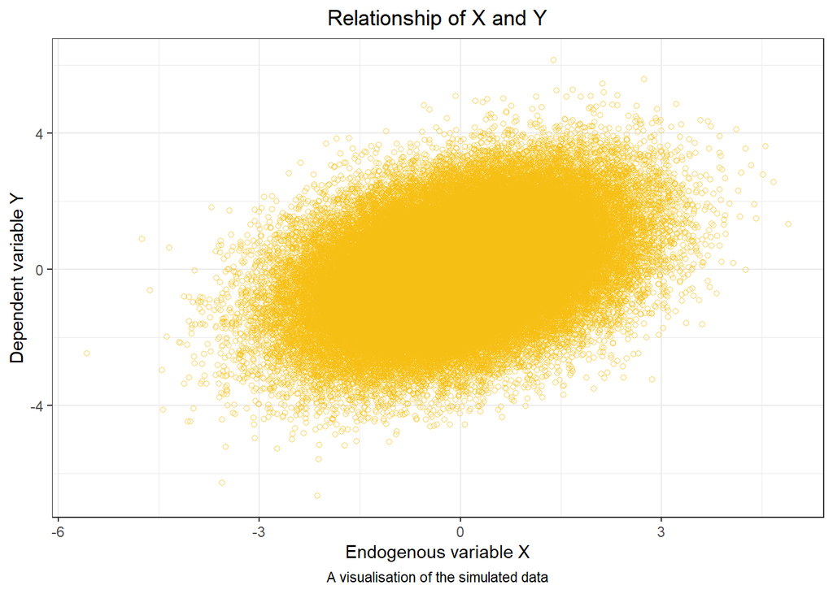

```r
ggplot(d, aes(x = X, y = Y)) +
  geom_point(shape=1, color="#F6BF14", alpha=0.7) +
  labs(x="Endogenous variable X", y="Dependent variable Y",
       title="Relationship of X and Y",
       caption="A visualisation of the simulated data") +
  theme_bw() +
  theme(plot.title = element_text(hjust = 0.5), plot.caption = element_text(hjust = 0.5))
```

### Identification via Linear Regression

#### Benchmark

```r
# benchmark regression (incl. unobserved confounder)
model_bench <- lm(Y ~ X + U, d)
model_bench_summary <- summary(model_bench)

model_bench_summary
```

```
##
## Call:
## lm(formula = Y ~ X + U, data = d)
##
## Residuals:
##     Min      1Q  Median      3Q     Max
## -4.7615 -0.7629  0.0037  0.7627  5.0667
##
## Coefficients:
##              Estimate Std. Error t value            Pr(>|t|)
## (Intercept) -0.004919   0.003583  -1.373                0.17
## X            0.248234   0.003583  69.275 <0.0000000000000002 ***
## U            0.507100   0.004016 126.262 <0.0000000000000002 ***
## ---
## Signif. codes:  0 '***' 0.001 '**' 0.01 '*' 0.05 '.' 0.1 ' ' 1
##
## Residual standard error: 1.133 on 99997 degrees of freedom
## Multiple R-squared:  0.2628, Adjusted R-squared:  0.2628
## F-statistic: 1.782e+04 on 2 and 99997 DF,  p-value: < 0.00000000000000022
```

```r
print(
  paste0(
    "p-value(beta_X = 0.25): ",
    pval(
      coef = model_bench_summary$coefficients[2,1],
      cv = 0.25,
      se = model_bench_summary$coefficients[2,2],
      df = model_bench_summary$df[2]) %>%
      round(4)
  )
)
```

```
## [1] "p-value(beta_X = 0.25): 0.6222"
```

#### Naive

```r
# naive regression (excl. unobserved confounder)
model_naive <- lm(Y ~ X, d)
model_naive_summary <- summary(model_naive)

model_naive_summary
```

```
##
## Call:
## lm(formula = Y ~ X, data = d)
##
## Residuals:
##     Min      1Q  Median      3Q     Max
## -5.6812 -0.8200  0.0028  0.8238  5.5255
##
## Coefficients:
##              Estimate Std. Error t value            Pr(>|t|)
## (Intercept) -0.002278   0.003858   -0.59               0.555
## X            0.450124   0.003453  130.36 <0.0000000000000002 ***
## ---
## Signif. codes:  0 '***' 0.001 '**' 0.01 '*' 0.05 '.' 0.1 ' ' 1
##
## Residual standard error: 1.22 on 99998 degrees of freedom
## Multiple R-squared:  0.1453, Adjusted R-squared:  0.1452
## F-statistic: 1.699e+04 on 1 and 99998 DF,  p-value: < 0.00000000000000022
```

```r
print(
  paste0(
    "p-value(beta_X = 0.25): ",
    pval(
      coef = model_naive_summary$coefficients[2,1],
      cv = 0.25,
      se = model_naive_summary$coefficients[2,2],
      df = model_naive_summary$df[2]) %>%
      round(4)
  )
)
```

```
## [1] "p-value(beta_X = 0.25): 0"
```

#### FDC

```r
# seemingly unrelated regression
model_fd <- systemfit(list(first = M ~ X, second = Y ~ M + X), method = "SUR", data = d)
model_fd_summary <- summary(model_fd)
model_fd_summary
```

```
##
## systemfit results
## method: SUR
##
##             N     DF    SSR detRCov  OLS-R2 McElroy-R2
## system 200000 199995 230951 1.33051 0.26814         NA
##
##             N    DF    SSR     MSE    RMSE       R2  Adj R2
## first  100000 99998 109981 1.09984 1.04873 0.222288 0.22228
## second 100000 99997 120970 1.20973 1.09988 0.305374 0.30536
##
## The covariance matrix of the residuals used for estimation
##                          first                  second
## first   1.09983679527962308065 -0.00000000000000599864
## second -0.00000000000000599864  1.20973235290378799967
##
## The covariance matrix of the residuals
##                          first                  second
## first  1.099836795279622858601 0.000000000000000229679
## second 0.000000000000000229679 1.209732352903787999665
##
## The correlations of the residuals
##                          first                  second
## first  1.000000000000000000000 0.000000000000000199133
## second 0.000000000000000199133 1.000000000000000000000
##
##
## SUR estimates for 'first' (equation 1)
## Model Formula: M ~ X
##
##                Estimate  Std. Error  t value             Pr(>|t|)
## (Intercept) -0.00250817  0.00331639  -0.7563              0.44947
## X            0.50178125  0.00296804 169.0614 < 0.0000000000000002 ***
## ---
## Signif. codes:  0 '***' 0.001 '**' 0.01 '*' 0.05 '.' 0.1 ' ' 1
##
## Residual standard error: 1.048731 on 99998 degrees of freedom
## Number of observations: 100000 Degrees of Freedom: 99998
## SSR: 109981.479854 MSE: 1.099837 Root MSE: 1.048731
## Multiple R-Squared: 0.222288 Adjusted R-Squared: 0.22228
##
##
## SUR estimates for 'second' (equation 2)
## Model Formula: Y ~ M + X
##
##                Estimate  Std. Error   t value             Pr(>|t|)
## (Intercept) -0.00101478  0.00347814  -0.29176              0.77047
## M            0.50353090  0.00331654 151.82429 < 0.0000000000000002 ***
## X            0.19746126  0.00352973  55.94237 < 0.0000000000000002 ***
## ---
## Signif. codes:  0 '***' 0.001 '**' 0.01 '*' 0.05 '.' 0.1 ' ' 1
##
## Residual standard error: 1.099878 on 99997 degrees of freedom
## Number of observations: 100000 Degrees of Freedom: 99997
## SSR: 120969.606093 MSE: 1.209732 Root MSE: 1.099878
## Multiple R-Squared: 0.305374 Adjusted R-Squared: 0.30536
```

```r
# computation of ATE by multiplying coefficients
ate_fd <- as.numeric(model_fd$coefficients["first_X"] * model_fd$coefficients["second_M"])
# get variance-covariance matrix of coefficients
ate_fd_cov <- model_fd$coefCov[c("first_X", "second_M"), c("first_X", "second_M")]
# get jacobian for Delta-method
jacobian <- as.matrix(rev(model_fd$coefficients[c("first_X", "second_M")]))
# apply Delta-method to compute ATE standard error
ate_fd_se <- sqrt(t(jacobian) %*% ate_fd_cov %*% jacobian)

cat(
  'ATE: ', round(ate_fd, 4),
  '\nse(ATE): ', round(ate_fd_se, 4),
  '\np-value(ATE = 0.25): ', round(pval(coef=ate_fd, cv=0.25, se=ate_fd_se, df=model_fd_summary$df[2]), 4)
)
```

```
## ATE:  0.2527
## se(ATE):  0.0022
## p-value(ATE = 0.25):  0.2339
```

#### Direct Effect (all variables included)

```r
# seemingly unrelated regression
model_direct <- lm(Y ~ X + M + U, d)
model_direct_summary <- summary(model_direct)
model_direct_summary
```

```
##
## Call:
## lm(formula = Y ~ X + M + U, data = d)
##
## Residuals:
##     Min      1Q  Median      3Q     Max
## -4.4227 -0.6762 -0.0003  0.6782  4.5828
##
## Coefficients:
##              Estimate Std. Error t value            Pr(>|t|)
## (Intercept) -0.003655   0.003171  -1.153               0.249
## X           -0.004199   0.003515  -1.195               0.232
## M            0.503313   0.003023 166.476 <0.0000000000000002 ***
## U            0.506801   0.003554 142.605 <0.0000000000000002 ***
## ---
## Signif. codes:  0 '***' 0.001 '**' 0.01 '*' 0.05 '.' 0.1 ' ' 1
##
## Residual standard error: 1.003 on 99996 degrees of freedom
## Multiple R-squared:  0.4228, Adjusted R-squared:  0.4227
## F-statistic: 2.441e+04 on 3 and 99996 DF,  p-value: < 0.00000000000000022
```

## Additional observed confounder FDC

### Set-up

Let $D_i \sim \mathcal{N}(0,1)$ be an additional observed confounder that drives both selection into treatment and the mediator while affecting the outcome $Y_i$ as well. Then, let
$$X_i = 0.5U_i + 0.5D_i + \epsilon_{X_i} \\
M_i = Z_iX_i + 0.3D_i + \epsilon_{M_i} \\
Y_i = 0.5M_i + 0.5U_i + 0.15D_i + \epsilon_{Y_i}$$

```r
# observed confounder
D <- rnorm(n, mean = 0, sd = 1)

X <- 0.5*U + 0.5*D + e_X
M <- Z*X + 0.3*D + e_M
Y <- 0.5*M + 0.5*U + 0.15*D + e_Y

d <- data.frame(cbind(U, X, M, Y, D))
```

### Identification via Linear Regression

#### Benchmark

```r
# benchmark regression (incl. unobserved und observed confounders)
model_bench <- lm(Y ~ X + U + D, d)
model_bench_summary <- summary(model_bench)

model_bench_summary
```

```
##
## Call:
## lm(formula = Y ~ X + U + D, data = d)
##
## Residuals:
##     Min      1Q  Median      3Q     Max
## -4.7786 -0.7663  0.0009  0.7633  5.0706
##
## Coefficients:
##              Estimate Std. Error t value            Pr(>|t|)
## (Intercept) -0.005057   0.003591  -1.408               0.159
## X            0.248287   0.003591  69.142 <0.0000000000000002 ***
## U            0.507550   0.004025 126.104 <0.0000000000000002 ***
## D            0.307762   0.004020  76.555 <0.0000000000000002 ***
## ---
## Signif. codes:  0 '***' 0.001 '**' 0.01 '*' 0.05 '.' 0.1 ' ' 1
##
## Residual standard error: 1.136 on 99996 degrees of freedom
## Multiple R-squared:  0.3329, Adjusted R-squared:  0.3329
## F-statistic: 1.663e+04 on 3 and 99996 DF,  p-value: < 0.00000000000000022
```

#### Naive

```r
# naive regression (excl. unobserved confounder and incl. observed confounder)
model_naive <- lm(Y ~ X + D, d)
model_naive_summary <- summary(model_naive)

model_naive_summary
```

```
##
## Call:
## lm(formula = Y ~ X + D, data = d)
##
## Residuals:
##     Min      1Q  Median      3Q     Max
## -5.6987 -0.8211  0.0023  0.8233  5.5456
##
## Coefficients:
##              Estimate Std. Error t value            Pr(>|t|)
## (Intercept) -0.002413   0.003866  -0.624               0.533
## X            0.450355   0.003460 130.170 <0.0000000000000002 ***
## D            0.206442   0.004241  48.681 <0.0000000000000002 ***
## ---
## Signif. codes:  0 '***' 0.001 '**' 0.01 '*' 0.05 '.' 0.1 ' ' 1
##
## Residual standard error: 1.222 on 99997 degrees of freedom
## Multiple R-squared:  0.2268, Adjusted R-squared:  0.2268
## F-statistic: 1.467e+04 on 2 and 99997 DF,  p-value: < 0.00000000000000022
```

#### FDC

```r
model_fd <- systemfit(list(first = M ~ X + D, second = Y ~ M + X + D), method = "SUR", data = d)
model_fd_summary <- summary(model_fd)
model_fd_summary
```

```
##
## systemfit results
## method: SUR
##
##             N     DF    SSR detRCov   OLS-R2 McElroy-R2
## system 200000 199993 233128 1.35687 0.365422         NA
##
##             N    DF    SSR     MSE    RMSE       R2   Adj R2
## first  100000 99997 112161 1.12164 1.05907 0.355777 0.355764
## second 100000 99996 120967 1.20972 1.09987 0.374110 0.374091
##
## The covariance matrix of the residuals used for estimation
##                        first                second
## first  1.1216395212185990005 0.0000000000000118518
## second 0.0000000000000118518 1.2097179850164025972
##
## The covariance matrix of the residuals
##                         first                 second
## first  1.12163952121859900046 0.00000000000000687234
## second 0.00000000000000687234 1.20971798501640259715
##
## The correlations of the residuals
##                         first                 second
## first  1.00000000000000000000 0.00000000000000589973
## second 0.00000000000000589973 1.00000000000000000000
##
##
## SUR estimates for 'first' (equation 1)
## Model Formula: M ~ X + D
##
##                Estimate  Std. Error   t value             Pr(>|t|)
## (Intercept) -0.00276957  0.00334910  -0.82696              0.40826
## X            0.50223540  0.00299732 167.56168 < 0.0000000000000002 ***
## D            0.30236690  0.00367386  82.30222 < 0.0000000000000002 ***
## ---
## Signif. codes:  0 '***' 0.001 '**' 0.01 '*' 0.05 '.' 0.1 ' ' 1
##
## Residual standard error: 1.059075 on 99997 degrees of freedom
## Number of observations: 100000 Degrees of Freedom: 99997
## SSR: 112160.587203 MSE: 1.12164 Root MSE: 1.059075
## Multiple R-Squared: 0.355777 Adjusted R-Squared: 0.355764
##
##
## SUR estimates for 'second' (equation 2)
## Model Formula: Y ~ M + X + D
##
##                Estimate  Std. Error   t value             Pr(>|t|)
## (Intercept) -0.00101743  0.00347812  -0.29252              0.76989
## M            0.50383392  0.00328414 153.41417 < 0.0000000000000002 ***
## X            0.19731188  0.00352277  56.01036 < 0.0000000000000002 ***
## D            0.05409904  0.00394249  13.72205 < 0.0000000000000002 ***
## ---
## Signif. codes:  0 '***' 0.001 '**' 0.01 '*' 0.05 '.' 0.1 ' ' 1
##
## Residual standard error: 1.099872 on 99996 degrees of freedom
## Number of observations: 100000 Degrees of Freedom: 99996
## SSR: 120966.95963 MSE: 1.209718 Root MSE: 1.099872
## Multiple R-Squared: 0.37411 Adjusted R-Squared: 0.374091
```

```r
ate_fd <- as.numeric(model_fd$coefficients["first_X"] * model_fd$coefficients["second_M"])
ate_fd_cov <- model_fd$coefCov[c("first_X", "second_M"), c("first_X", "second_M")]
jacobian <- as.matrix(rev(model_fd$coefficients[c("first_X", "second_M")]))
ate_fd_se <- sqrt(t(jacobian) %*% ate_fd_cov %*% jacobian)

cat(
  'ATE: ', round(ate_fd, 4),
  '\nse(ATE): ', round(ate_fd_se, 4),
  '\np-value(ATE = 0.25): ', round(pval(coef=ate_fd, cv=0.25, se=ate_fd_se, df=model_fd_summary$df[2]), 4)
)
```

```
## ATE:  0.253
## se(ATE):  0.0022
## p-value(ATE = 0.25):  0.1736
```

## Parallel mediator case FDC

### Set-up

In the ‘parallel’ mediator case, there are two mediators that both lie on their own separate directed path from X to Y. Put differently, there is a path flowing from X via M1 to Y and a second path from X via M2 to Y. Hence, when not controlling for / conditioning on both mediators, assumption 1 of the FDC would be violated as all directed paths from X to Y have to be intercepted.

Assuming that additionally $Z_{1i}, Z_{2i} \stackrel{i.i.d.}{\sim} \mathcal{U}(0,1)$ and $\epsilon_{M_{1i}}, \epsilon_{M_{2i}} \stackrel{i.i.d.}{\sim} \mathcal{N}(0,1)$, then, let
$$X_i = 0.5U_i + \epsilon_{X_i} \\
M_{1i} = Z_{1i}X_i + \epsilon_{M_{1i}} \\
M_{2i} = Z_{2i}X_i + \epsilon_{M_{2i}} \\
Y_i = 0.5M_{1i} + 0.5M_{2i} + 0.5U_i + \epsilon_{Y_i}$$

```r
# random effects
Z1 <- runif(n, min = 0, max = 1)
Z2 <- runif(n, min = 0, max = 1)
# errors
e_M1 <- rnorm(n, mean = 0, sd = 1)
e_M2 <- rnorm(n, mean = 0, sd = 1)

X <- 0.5*U + e_X
M1 <- Z1*X + e_M1
M2 <- Z2*X + e_M2
Y <- 0.5*M1 + 0.5*M2 + 0.5*U + e_Y

d <- data.frame(cbind(U, X, M1, M2, Y))
```

### Identification via Linear Regression

#### Benchmark

```r
# benchmark regression
model_bench <- lm(Y ~ X + U, d)
model_bench_summary <- summary(model_bench)

model_bench_summary
```

```
##
## Call:
## lm(formula = Y ~ X + U, data = d)
##
## Residuals:
##     Min      1Q  Median      3Q     Max
## -5.3599 -0.8440  0.0048  0.8391  5.5188
##
## Coefficients:
##              Estimate Std. Error t value            Pr(>|t|)
## (Intercept) -0.004456   0.003938  -1.131               0.258
## X            0.494063   0.003938 125.456 <0.0000000000000002 ***
## U            0.512213   0.004414 116.045 <0.0000000000000002 ***
## ---
## Signif. codes:  0 '***' 0.001 '**' 0.01 '*' 0.05 '.' 0.1 ' ' 1
##
## Residual standard error: 1.245 on 99997 degrees of freedom
## Multiple R-squared:  0.3451, Adjusted R-squared:  0.3451
## F-statistic: 2.634e+04 on 2 and 99997 DF,  p-value: < 0.00000000000000022
```

#### FDC

```r
model_fd <- systemfit(list(first = M1 ~ X, second = M2 ~ X, third = Y ~ M1 + M2 + X), method = "SUR", data = d)
model_fd_summary <- summary(model_fd)
model_fd_summary
```

```
##
## systemfit results
## method: SUR
##
##             N     DF    SSR detRCov   OLS-R2 McElroy-R2
## system 300000 299992 340761 1.46106 0.343042         NA
##
##             N    DF    SSR     MSE    RMSE       R2   Adj R2
## first  100000 99998 110068 1.10070 1.04914 0.224722 0.224714
## second 100000 99998 109723 1.09725 1.04750 0.215955 0.215947
## third  100000 99996 120970 1.20975 1.09989 0.489101 0.489085
##
## The covariance matrix of the residuals used for estimation
##                         first                 second                   third
## first  1.10070026848361424143  0.0017301699344468516  0.00000000000000571524
## second 0.00173016993444685165  1.0972496288450779289 -0.00000000000001937889
## third  0.00000000000000571524 -0.0000000000000193789  1.20974796353709002084
##
## The covariance matrix of the residuals
##                        first                 second                  third
## first  1.1007002684836142414  0.0017301699344468516  0.0000000000000213426
## second 0.0017301699344468516  1.0972496288450779289 -0.0000000000000289787
## third  0.0000000000000213426 -0.0000000000000289787  1.2097479635370900208
##
## The correlations of the residuals
##                        first                 second                  third
## first  1.0000000000000000000  0.0015743507790840895  0.0000000000000184953
## second 0.0015743507790840895  1.0000000000000000000 -0.0000000000000251521
## third  0.0000000000000184953 -0.0000000000000251521  1.0000000000000000000
##
##
## SUR estimates for 'first' (equation 1)
## Model Formula: M1 ~ X
##
##               Estimate Std. Error   t value             Pr(>|t|)
## (Intercept) 0.00159089 0.00331769   0.47952              0.63157
## X           0.50550982 0.00296921 170.25086 < 0.0000000000000002 ***
## ---
## Signif. codes:  0 '***' 0.001 '**' 0.01 '*' 0.05 '.' 0.1 ' ' 1
##
```

[output cut: 21 more lines]

```
## SUR estimates for 'third' (equation 3)
## Model Formula: Y ~ M1 + M2 + X
##
##                Estimate  Std. Error  t value             Pr(>|t|)
## (Intercept) -0.00101390  0.00347817  -0.2915              0.77067
## M1           0.49762448  0.00331526 150.1011 < 0.0000000000000002 ***
## M2           0.50191015  0.00332047 151.1563 < 0.0000000000000002 ***
## X            0.19949406  0.00389339  51.2391 < 0.0000000000000002 ***
## ---
## Signif. codes:  0 '***' 0.001 '**' 0.01 '*' 0.05 '.' 0.1 ' ' 1
##
## Residual standard error: 1.099885 on 99996 degrees of freedom
## Number of observations: 100000 Degrees of Freedom: 99996
## SSR: 120969.957362 MSE: 1.209748 Root MSE: 1.099885
## Multiple R-Squared: 0.489101 Adjusted R-Squared: 0.489085
```

```r
# help filter vector
f <- c("first_X", "second_X", "third_M1", "third_M2")
ate_fd <- as.numeric(model_fd$coefficients["first_X"] * model_fd$coefficients["third_M1"] + model_fd$coefficients["second_X"] * model_fd$coefficients["third_M2"])
ate_fd_cov <- model_fd$coefCov[f, f]
jacobian <- as.matrix(model_fd$coefficients[c("third_M1", "third_M2", "first_X", "second_X")])
ate_fd_se <- sqrt(t(jacobian) %*% ate_fd_cov %*% jacobian)

cat(
  'ATE: ', round(ate_fd, 4),
  '\nse(ATE): ', round(ate_fd_se, 4),
  '\np-value(ATE = 0.5): ', round(pval(coef=ate_fd, cv=0.5, se=ate_fd_se, df=model_fd_summary$df[2]), 4)
)
```

```
## ATE:  0.4985
## se(ATE):  0.0031
## p-value(ATE = 0.5):  0.6317
```

## Sequential mediator case FDC

### Set-up

In contrast, the ‘sequential’ mediator case marks a somewhat nested structure where both mediators lie on the same and the only directed path from X to Y (i.e. there is a path flowing from X via M1 via M2 to Y. This relaxes the requirements to arrive at a causal estimate to some extent as one only needs to control for one of the two mediators being sufficient to intercept all directed paths from X to Y. Let
$$X_i = 0.5U_i + \epsilon_{X_i} \\
M_{1i} = Z_{1i}X_i + \epsilon_{M_{1i}} \\
M_{2i} = Z_{2i}M_{1i} + \epsilon_{M_{2i}} \\
Y_i = 0.5M_{2i} + 0.5U_i + \epsilon_{Y_i}$$

```r
M1 <- Z1*X + e_M1
M2 <- Z2*M1 + e_M2
Y <- 0.5*M2 + 0.5*U + e_Y

d <- data.frame(cbind(U, X, M1, M2, Y))
```

### Identification via Linear Regression

#### Benchmark

```r
# benchmark regression
model_bench <- lm(Y ~ X + U, d)
model_bench_summary <- summary(model_bench)

model_bench_summary
```

```
##
## Call:
## lm(formula = Y ~ X + U, data = d)
##
## Residuals:
##     Min      1Q  Median      3Q     Max
## -5.0799 -0.7817  0.0038  0.7849  5.2327
##
## Coefficients:
##              Estimate Std. Error t value            Pr(>|t|)
## (Intercept) -0.004571   0.003676  -1.243               0.214
## X            0.118178   0.003677  32.144 <0.0000000000000002 ***
## U            0.510769   0.004121 123.951 <0.0000000000000002 ***
## ---
## Signif. codes:  0 '***' 0.001 '**' 0.01 '*' 0.05 '.' 0.1 ' ' 1
##
## Residual standard error: 1.163 on 99997 degrees of freedom
## Multiple R-squared:  0.1995, Adjusted R-squared:  0.1994
## F-statistic: 1.246e+04 on 2 and 99997 DF,  p-value: < 0.00000000000000022
```

#### FDC using both mediators

```r
model_fd <- systemfit(list(first = M1 ~ X, second = M2 ~ M1, third = Y ~ M1 + M2 + X), method = "SUR", data = d)
model_fd_summary <- summary(model_fd)
model_fd_summary
```

```
##
## systemfit results
## method: SUR
##
##             N     DF    SSR detRCov   OLS-R2 McElroy-R2
## system 300000 299992 342352 1.48219 0.251392         NA
##
##             N    DF    SSR     MSE    RMSE       R2   Adj R2
## first  100000 99998 110068 1.10070 1.04914 0.224722 0.224714
## second 100000 99998 111315 1.11317 1.05507 0.240278 0.240270
## third  100000 99996 120969 1.20974 1.09988 0.283466 0.283444
##
## The covariance matrix of the residuals used for estimation
##                          first                  second                    third
## first  1.100700268483614241433  0.00450888469820963974  0.000000000000000260741
## second 0.004508884698209639739  1.11315977188997194958 -0.000000000000004542281
## third  0.000000000000000260741 -0.00000000000000454228  1.209743002656276544826
##
## The covariance matrix of the residuals
##                          first                 second                   third
## first   1.10070026911199603248 0.00800463542117982665 -0.00000000000000525344
## second  0.00800463542117982665 1.11317409098769126707  0.00000000000000671254
## third  -0.00000000000000525344 0.00000000000000671254  1.20974300265627654483
##
## The correlations of the residuals
##                          first                 second                   third
## first   1.00000000000000000000 0.00723145145655784780 -0.00000000000000455251
## second  0.00723145145655784780 1.00000000000000000000  0.00000000000000578442
## third  -0.00000000000000455251 0.00000000000000578442  1.00000000000000000000
##
##
## SUR estimates for 'first' (equation 1)
## Model Formula: M1 ~ X
##
##               Estimate Std. Error   t value             Pr(>|t|)
## (Intercept) 0.00159095 0.00331769   0.47954              0.63156
## X           0.50553225 0.00296919 170.25951 < 0.0000000000000002 ***
## ---
## Signif. codes:  0 '***' 0.001 '**' 0.01 '*' 0.05 '.' 0.1 ' ' 1
##
```

[output cut: 21 more lines]

```
## SUR estimates for 'third' (equation 3)
## Model Formula: Y ~ M1 + M2 + X
##
##                Estimate  Std. Error   t value             Pr(>|t|)
## (Intercept) -0.00101256  0.00347816  -0.29112              0.77096
## M1          -0.00379736  0.00370550  -1.02479              0.30546
## M2           0.50283789  0.00329677 152.52457 < 0.0000000000000002 ***
## X            0.20045848  0.00353541  56.70024 < 0.0000000000000002 ***
## ---
## Signif. codes:  0 '***' 0.001 '**' 0.01 '*' 0.05 '.' 0.1 ' ' 1
##
## Residual standard error: 1.099883 on 99996 degrees of freedom
## Number of observations: 100000 Degrees of Freedom: 99996
## SSR: 120969.461294 MSE: 1.209743 Root MSE: 1.099883
## Multiple R-Squared: 0.283466 Adjusted R-Squared: 0.283444
```

```r
# help filter vector
f <- c("first_X", "second_M1", "third_M2")
ate_fd <- as.numeric(model_fd$coefficients["first_X"] * model_fd$coefficients["second_M1"] * model_fd$coefficients["third_M2"])
ate_fd_cov <- model_fd$coefCov[f, f]
jacobian <- c(
  model_fd$coefficients["second_M1"] * model_fd$coefficients["third_M2"],
  model_fd$coefficients["first_X"] * model_fd$coefficients["third_M2"],
  model_fd$coefficients["first_X"] * model_fd$coefficients["second_M1"]
  )
ate_fd_se <- sqrt(t(jacobian) %*% ate_fd_cov %*% jacobian)

cat(
  'ATE: ', round(ate_fd, 4),
  '\nse(ATE): ', round(ate_fd_se, 4),
  '\np-value(ATE = 0.125): ', round(pval(coef=ate_fd, cv=0.125, se=ate_fd_se, df=model_fd_summary$df[2]), 4)
)
```

```
## ATE:  0.1258
## se(ATE):  0.0013
## p-value(ATE = 0.125):  0.5536
```

#### FDC using only the second mediator M2

```r
model_fd <- systemfit(list(first = M2 ~ X, third = Y ~ M2 + X), method = "SUR", data = d)
model_fd_summary <- summary(model_fd)
model_fd_summary
```

```
##
## systemfit results
## method: SUR
##
##             N     DF    SSR detRCov   OLS-R2 McElroy-R2
## system 200000 199995 260022  1.6822 0.175439         NA
##
##            N    DF    SSR     MSE    RMSE       R2   Adj R2
## first 100000 99998 139052 1.39054 1.17921 0.050976 0.050967
## third 100000 99997 120971 1.20974 1.09988 0.283458 0.283444
##
## The covariance matrix of the residuals used for estimation
##                         first                   third
## first  1.39054538296865271008 -0.00000000000000439337
## third -0.00000000000000439337  1.20974360995069818436
##
## The covariance matrix of the residuals
##                        first                  third
## first  1.3905453829686527101 -0.0000000000000190598
## third -0.0000000000000190598  1.2097436099506981844
##
## The correlations of the residuals
##                        first                  third
## first  1.0000000000000000000 -0.0000000000000146955
## third -0.0000000000000146955  1.0000000000000000000
##
##
## SUR estimates for 'first' (equation 1)
## Model Formula: M2 ~ X
##
##                Estimate  Std. Error  t value             Pr(>|t|)
## (Intercept) -0.00177432  0.00372901 -0.47581              0.63421
## X            0.24459092  0.00333732 73.28954 < 0.0000000000000002 ***
## ---
## Signif. codes:  0 '***' 0.001 '**' 0.01 '*' 0.05 '.' 0.1 ' ' 1
##
## Residual standard error: 1.179214 on 99998 degrees of freedom
## Number of observations: 100000 Degrees of Freedom: 99998
## SSR: 139051.757206 MSE: 1.390545 Root MSE: 1.179214
## Multiple R-Squared: 0.050976 Adjusted R-Squared: 0.050967
##
##
## SUR estimates for 'third' (equation 2)
## Model Formula: Y ~ M2 + X
##
##                Estimate  Std. Error   t value             Pr(>|t|)
## (Intercept) -0.00102128  0.00347815  -0.29363              0.76904
## M2           0.50132872  0.00294957 169.96682 < 0.0000000000000002 ***
## X            0.19890801  0.00319532  62.24986 < 0.0000000000000002 ***
## ---
## Signif. codes:  0 '***' 0.001 '**' 0.01 '*' 0.05 '.' 0.1 ' ' 1
##
## Residual standard error: 1.099883 on 99997 degrees of freedom
## Number of observations: 100000 Degrees of Freedom: 99997
## SSR: 120970.731764 MSE: 1.209744 Root MSE: 1.099883
## Multiple R-Squared: 0.283458 Adjusted R-Squared: 0.283444
```

```r
# help filter vector
f <- c("first_X", "third_M2")
ate_fd <- as.numeric(model_fd$coefficients["first_X"] * model_fd$coefficients["third_M2"])
ate_fd_cov <- model_fd$coefCov[f, f]
jacobian <- as.matrix(model_fd$coefficients[c("third_M2", "first_X")])
ate_fd_se <- sqrt(t(jacobian) %*% ate_fd_cov %*% jacobian)

cat(
  'ATE: ', round(ate_fd, 4),
  '\nse(ATE): ', round(ate_fd_se, 4),
  '\np-value(ATE = 0.125): ', round(pval(coef=ate_fd, cv=0.125, se=ate_fd_se, df=model_fd_summary$df[2]), 4)
)
```

```
## ATE:  0.1226
## se(ATE):  0.0018
## p-value(ATE = 0.125):  0.1916
```

### Comparison

| Simulation | Annotation |
| --- | --- |
| Standard FDC | Causal effect is identified |
| Two mediator case | Causal effect is identified |
| Nested mediator case | / |